# Ch8 Themes

# Ch8 Themes

## Introduction

In this chapter you will learn how to use the ggplot2 theme system, which allows you to exercise fine control over the non-data elements of your plot. The theme system does not affect how the data is rendered by geoms, or how it is transformed by scales. Themes don’t change the perceptual properties of the plot, but they do help you make the plot aesthetically pleasing or match an existing style guide. Themes give you control over things like fonts, ticks, panel strips, and backgrounds.

This separation of control into data and non-data parts is quite different from base and lattice graphics. In base and lattice graphics, most functions take a large number of arguments that specify both data and non-data appearance, which makes the functions complicated and harder to learn. ggplot2 takes a different approach: when creating the plot you determine how the data is displayed, then *after* it has been created you can edit every detail of the rendering, using the theming system.

The theming system is composed of four main components:

- Theme **elements** specify the non-data elements that you can control. For example, the `plot.title` element controls the appearance of the plot title; `axis.ticks.x`, the ticks on the x axis; `legend.key.height`, the height of the keys in the legend.
- Each element is associated with an **element function**, which describes the visual properties of the element. For example, `element_text()` sets the font size, colour and face of text elements like `plot.title`.
- The `theme()` function which allows you to override the default theme elements by calling element functions, like `theme(plot.title = element_text(colour = "red"))`.
- Complete **themes**, like `theme_grey()` set all of the theme elements to values designed to work together harmoniously.

For example, imagine you’ve made the following plot of your data.

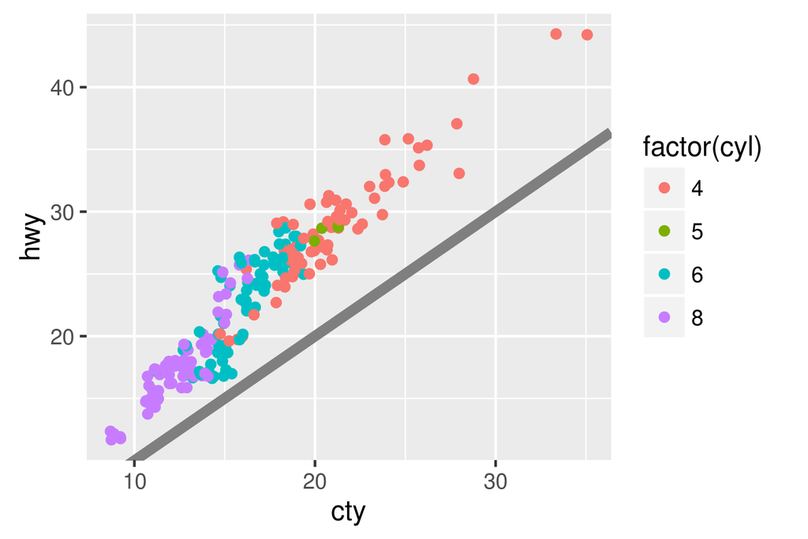

```r
base <- ggplot(mpg, aes(cty, hwy, color = factor(cyl))) +
  geom_jitter() +
  geom_abline(colour = "grey50", size = 2)
base
```

It’s served its purpose for you: you’ve learned that `cty` and `hwy` are highly correlated, both are tightly coupled with `cyl`, and that `hwy` is always greater than `cty` (and the difference increases as `cty` increases). Now you want to share the plot with others, perhaps by publishing it in a paper. That requires some changes. First, you need to make sure the plot can stand alone by:

- Improving the axes and legend labels.
- Adding a title for the plot.
- Tweaking the colour scale.

Fortunately you know how to do that already because you’ve read the scales chapter:

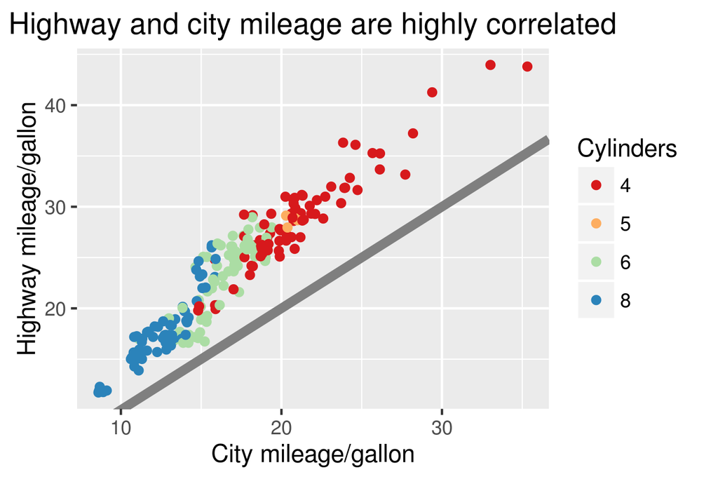

```r
labelled <- base +
  labs(
    x = "City mileage/gallon",
    y = "Highway mileage/gallon",
    colour = "Cylinders",
    title = "Highway and city mileage are highly correlated"
  ) +
  scale_colour_brewer(type = "seq", palette = "Spectral")
labelled
```

Next, you need to make sure the plot matches the style guidelines of your journal:

- The background should be white, not pale grey.
- The legend should be placed inside the plot if there’s room.
- Major gridlines should be a pale grey and minor gridlines should be removed.
- The plot title should be 12pt bold text.

In this chapter, you’ll learn how to use the theming system to make those changes, as shown below:

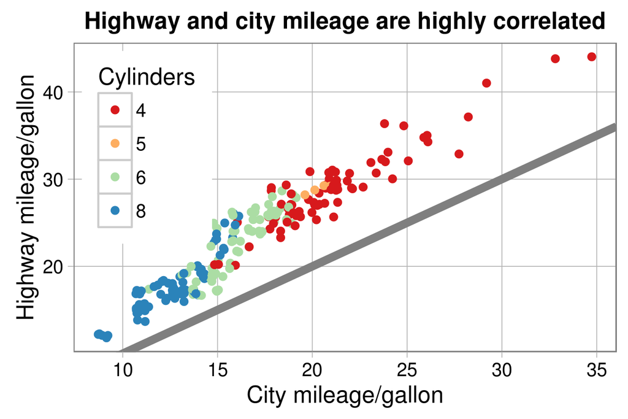

```r
styled <- labelled +
  theme_bw() +
  theme(
    plot.title = element_text(face = "bold", size = 12),
    legend.background = element_rect(fill = "white", size = 4, colour = "white"),
    legend.justification = c(0, 1),
    legend.position = c(0, 1),
    axis.ticks = element_line(colour = "grey70", size = 0.2),
    panel.grid.major = element_line(colour = "grey70", size = 0.2),
    panel.grid.minor = element_blank()
  )
styled
```

Finally, the journal wants the figure as a 600 dpi TIFF file. You’ll learn the fine details of `ggsave()` in saving your output.

## Complete themes

ggplot2 comes with a number of built in themes. The most important is `theme_grey()`, the signature ggplot2 theme with a light grey background and white gridlines. The theme is designed to put the data forward while supporting comparisons, following the advice of (Tufte 2006; Brewer 1994; Carr 2002; Carr 1994; Carr and Sun 1999). We can still see the gridlines to aid in the judgement of position (Cleveland 1993), but they have little visual impact and we can easily ‘tune’ them out. The grey background gives the plot a similar typographic colour to the text, ensuring that the graphics fit in with the flow of a document without jumping out with a bright white background. Finally, the grey background creates a continuous field of colour which ensures that the plot is perceived as a single visual entity.

There are seven other themes built in to ggplot2 1.1.0:

- `theme_bw()`: a variation on `theme_grey()` that uses a white background and thin grey grid lines.
- `theme_linedraw()`: A theme with only black lines of various widths on white backgrounds, reminiscent of a line drawing.
- `theme_light()`: similar to `theme_linedraw()` but with light grey lines and axes, to direct more attention towards the data.
- `theme_dark()`: the dark cousin of `theme_light()`, with similar line sizes but a dark background. Useful to make thin coloured lines pop out.
- `theme_minimal()`: A minimalistic theme with no background annotations.
- `theme_classic()`: A classic-looking theme, with x and y axis lines and no gridlines.
- `theme_void()`: A completely empty theme.

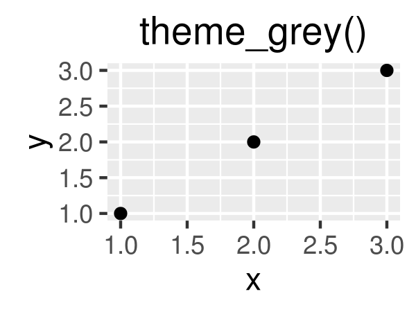

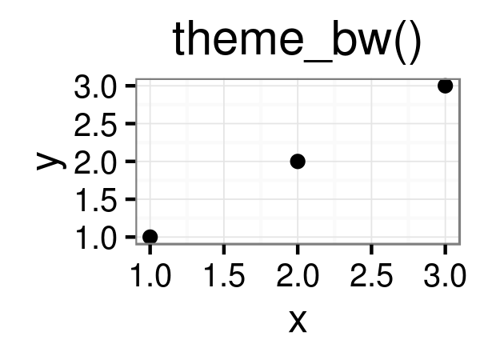

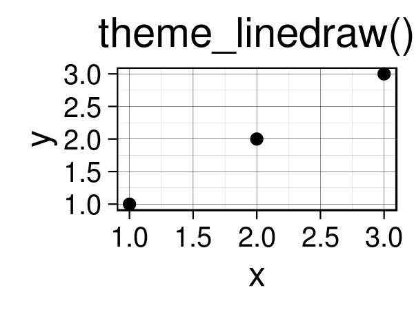

```r
df <- data.frame(x = 1:3, y = 1:3)
base <- ggplot(df, aes(x, y)) + geom_point()
base + theme_grey() + ggtitle("theme_grey()")
base + theme_bw() + ggtitle("theme_bw()")
base + theme_linedraw() + ggtitle("theme_linedraw()")
```

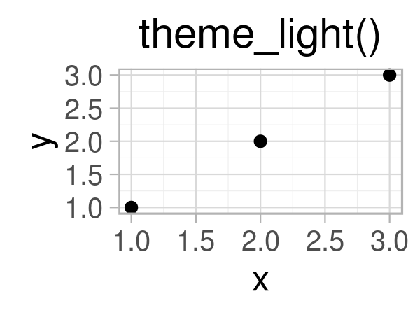

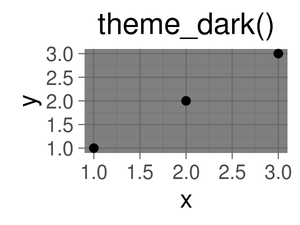

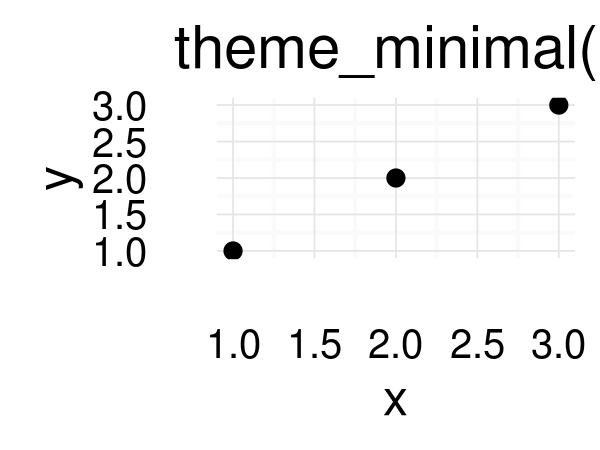

```r
base + theme_light() + ggtitle("theme_light()")
base + theme_dark() + ggtitle("theme_dark()")
base + theme_minimal()  + ggtitle("theme_minimal()")
```

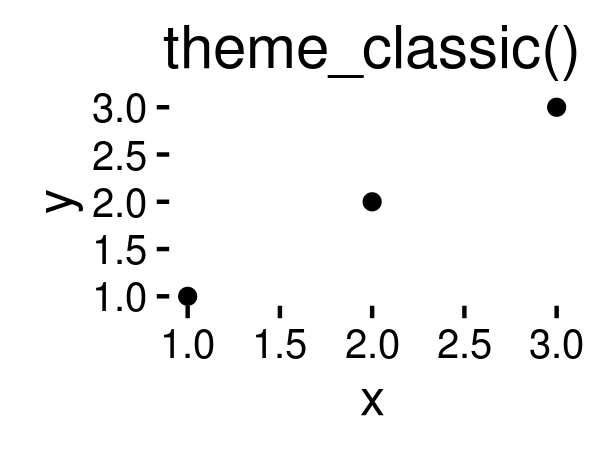

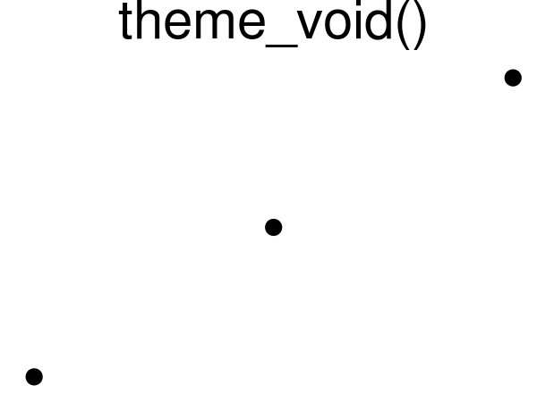

```r
base + theme_classic() + ggtitle("theme_classic()")
base + theme_void() + ggtitle("theme_void()")
```

All themes have a `base_size` parameter which controls the base font size. The base font size is the size that the axis titles use: the plot title is usually bigger (1.2x), and the tick and strip labels are smaller (0.8x). If you want to control these sizes separately, you’ll need to modify the individual elements as described below.

As well as applying themes a plot at a time, you can change the default theme with `theme_set()`. For example, if you really hate the default grey background, run `theme_set(theme_bw())` to use a white background for all plots.

You’re not limited to the themes built-in to ggplot2. Other packages, like ggthemes by Jeffrey Arnold, add even more. Here’s a few of my favourites from ggthemes:

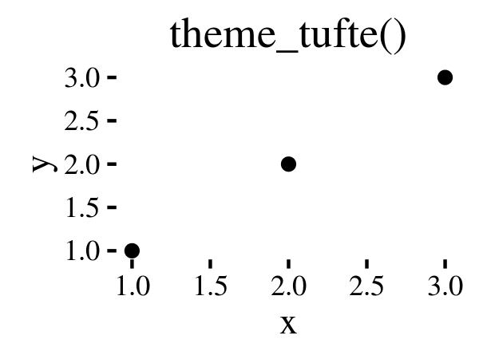

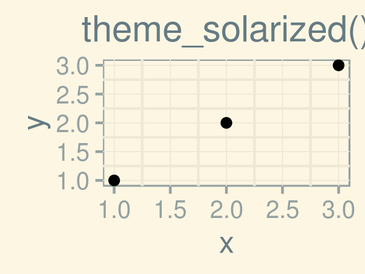

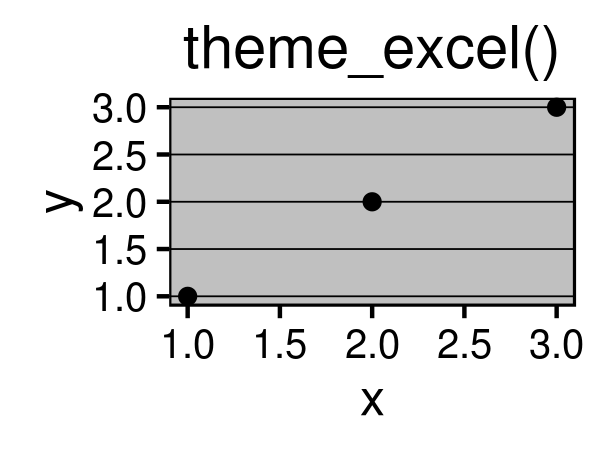

```r
library(ggthemes)
base + theme_tufte() + ggtitle("theme_tufte()")
base + theme_solarized() + ggtitle("theme_solarized()")
base + theme_excel() + ggtitle("theme_excel()") # ;)
```

The complete themes are a great place to start but don’t give you a lot of control. To modify individual elements, you need to use `theme()` to override the default setting for an element with an element function.

### Exercises

1. Try out all the themes in ggthemes. Which do you like the best?
2. What aspects of the default theme do you like? What don’t you like?  
   What would you change?
3. Look at the plots in your favourite scientific journal. What theme do they most resemble? What are the main differences?

## Modifying theme components

To modify an individual theme component you use code like `plot + theme(element.name = element_function())`. In this section you’ll learn about the basic element functions, and then in the next section, you’ll see all the elements that you can modify.

There are four basic types of built-in element functions: text, lines, rectangles, and blank. Each element function has a set of parameters that control the appearance:

- `element_text()` draws labels and headings. You can control the font `family`, `face`, `colour`, `size` (in points), `hjust`, `vjust`, `angle` (in degrees) and `lineheight` (as ratio of `fontcase`). More details on the parameters can be found in `vignette("ggplot2-specs")`. Setting the font face is particularly challenging.

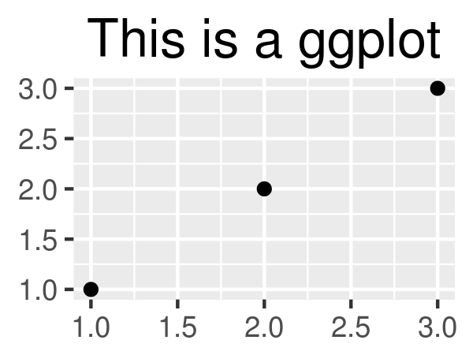

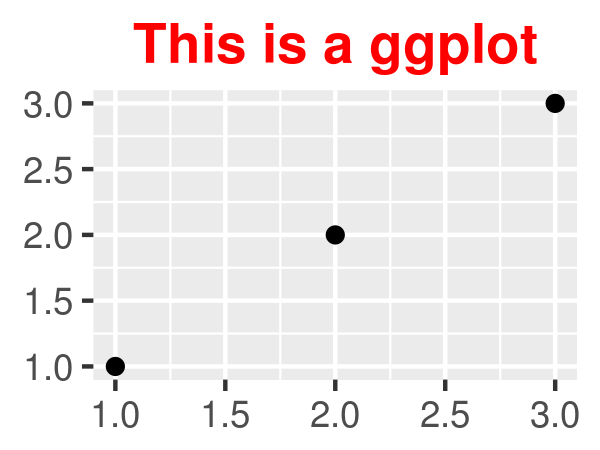

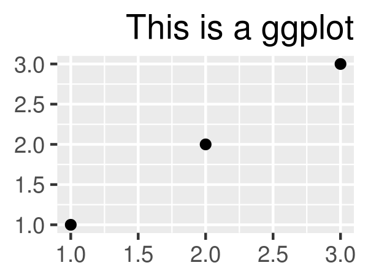

  ```r
  base_t <- base + labs(title = "This is a ggplot") + xlab(NULL) + ylab(NULL)
  base_t + theme(plot.title = element_text(size = 16))
  base_t + theme(plot.title = element_text(face = "bold", colour = "red"))
  base_t + theme(plot.title = element_text(hjust = 1))
  ```

  You can control the margins around the text with the `margin` argument and `margin()` function. `margin()` has four arguments: the amount of space (in points) to add to the top, right, bottom and left sides of the text. Any elements not specified default to 0.

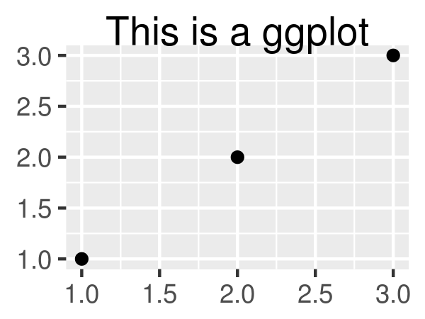

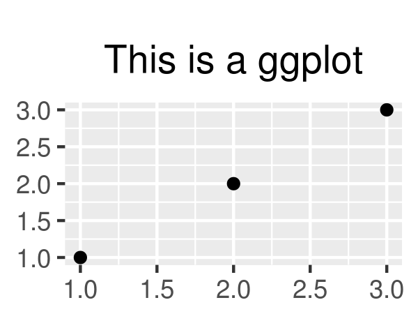

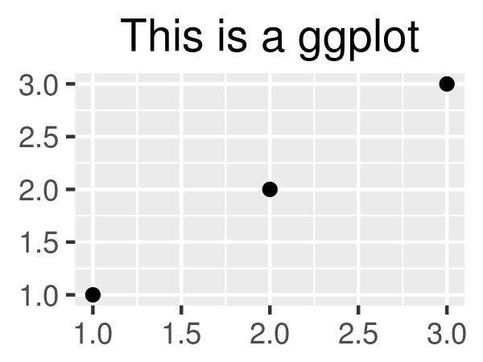

  ```r
  # The margins here look asymmetric because there are also plot margins
  base_t + theme(plot.title = element_text(margin = margin()))
  base_t + theme(plot.title = element_text(margin = margin(t = 10, b = 10)))
  base_t + theme(axis.title.y = element_text(margin = margin(r = 10)))
  ```

- `element_line()` draws lines parameterised by `colour`, `size` and `linetype`:

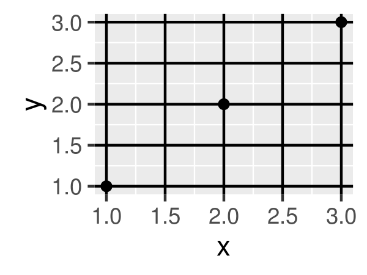

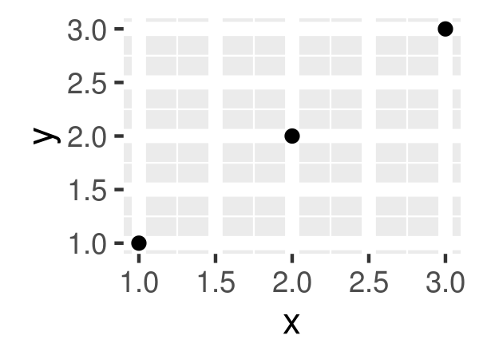

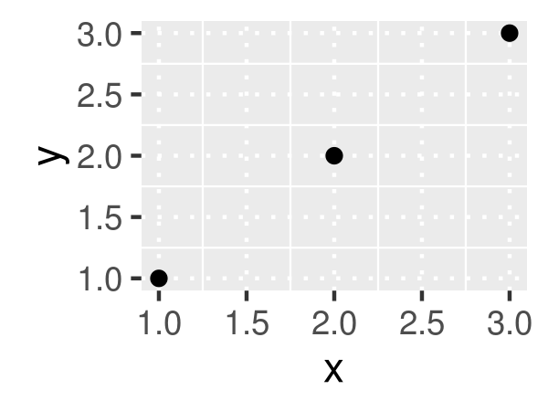

  ```r
  base + theme(panel.grid.major = element_line(colour = "black"))
  base + theme(panel.grid.major = element_line(size = 2))
  base + theme(panel.grid.major = element_line(linetype = "dotted"))
  ```

- `element_rect()` draws rectangles, mostly used for backgrounds, parameterised by `fill` colour and border `colour`, `size` and `linetype`.

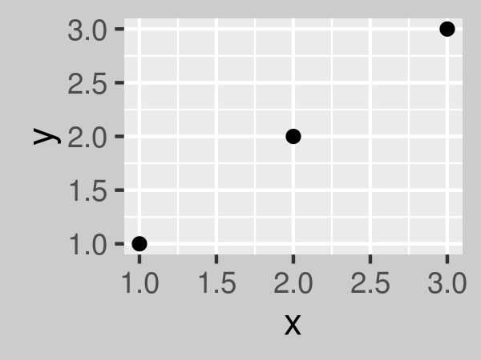

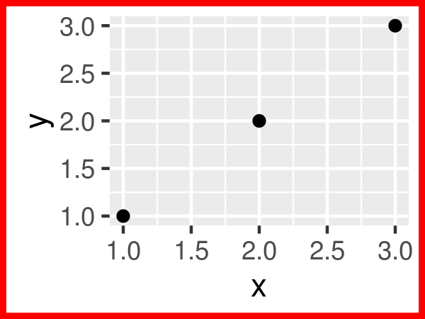

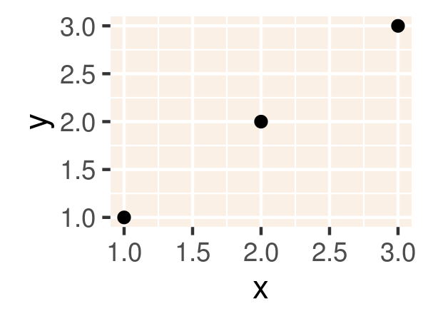

  ```r
  base + theme(plot.background = element_rect(fill = "grey80", colour = NA))
  base + theme(plot.background = element_rect(colour = "red", size = 2))
  base + theme(panel.background = element_rect(fill = "linen"))
  ```

- `element_blank()` draws nothing. Use this if you don’t want anything drawn, and no space allocated for that element. The following example uses `element_blank()` to progressively suppress the appearance of elements we’re not interested in. Notice how the plot automatically reclaims the space previously used by these elements: if you don’t want this to happen (perhaps because they need to line up with other plots on the page), use `colour = NA, fill = NA` to create invisible elements that still take up space.

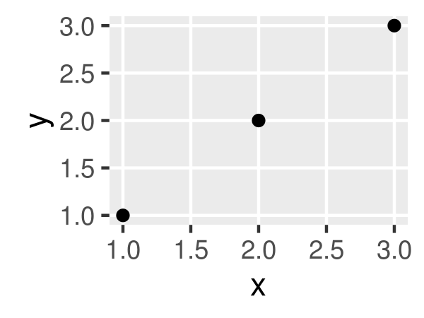

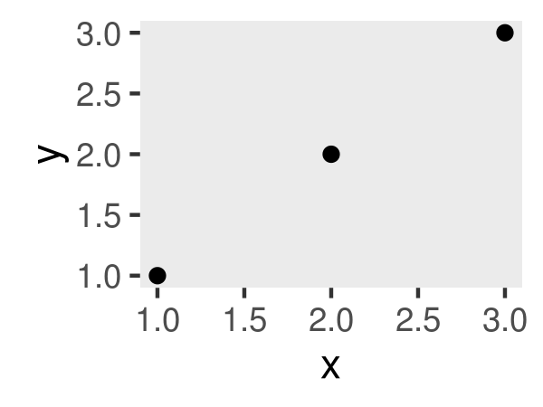

  ```r
  base
  last_plot() + theme(panel.grid.minor = element_blank())
  last_plot() + theme(panel.grid.major = element_blank())
  ```

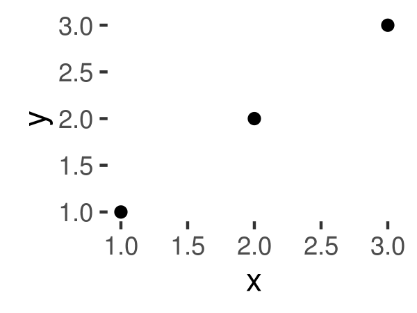

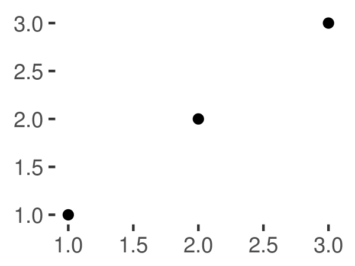

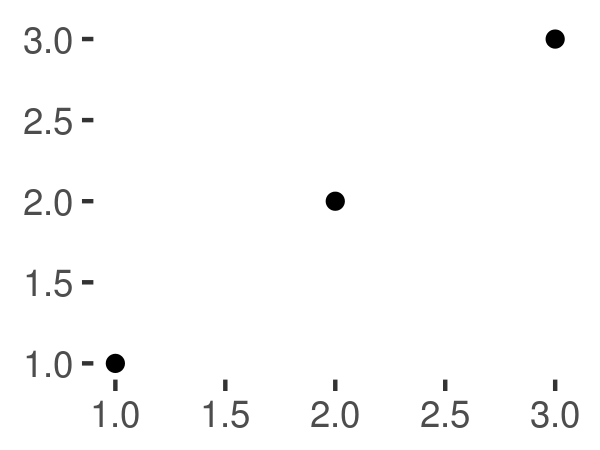

  ```r
  last_plot() + theme(panel.background = element_blank())
  last_plot() + theme(
    axis.title.x = element_blank(),
    axis.title.y = element_blank()
  )
  last_plot() + theme(axis.line = element_line(colour = "grey50"))
  ```

- A few other settings take grid units. Create them with `unit(1, "cm")` or `unit(0.25, "in")`.

To modify theme elements for all future plots, use `theme_update()`. It returns the previous theme settings, so you can easily restore the original parameters once you’re done.

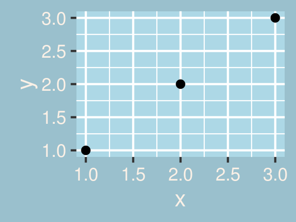

```r
old_theme <- theme_update(
  plot.background = element_rect(fill = "lightblue3", colour = NA),
  panel.background = element_rect(fill = "lightblue", colour = NA),
  axis.text = element_text(colour = "linen"),
  axis.title = element_text(colour = "linen")
)
base
theme_set(old_theme)
base
```